# Assignment 1: Dataset initial processing

BCB420 - Computational Systems Biology

Vivian Wang

February 14, 2023

# Packages installation

```r
if (!requireNamespace("BiocManager", quietly = TRUE)){
  install.packages("BiocManager")}

if (!requireNamespace("GEOmetadb", quietly = TRUE)){
  BiocManager::install("GEOmetadb")}

if (!requireNamespace("GEOquery", quietly = TRUE)){
  BiocManager::install("GEOquery")}

if (!requireNamespace("knitr", quietly = TRUE)){
  install.packages("knitr")}

if (!requireNamespace("edgeR", quietly = TRUE)){
  BiocManager::install("edgeR")}

if (!requireNamespace("biomaRt", quietly = TRUE)){
  BiocManager::install("biomaRt")}

if (! requireNamespace("limma", quietly = TRUE)) {
  BiocManager::install("limma")
}
```

# Dataset download and information

Our dataset of interest is GSE157852. From the previous data selection step, we learned that it is a bulk RNA-seq dataset associated with the paper, “Human Pluripotent Stem Cell-Derived Neural Cells and Brain Organoids Reveal SARS-CoV-2 Neurotropism Predominates in Choroid Plexus Epithelium” (Jacob et al. 2020).

First, we will inspect the information associated with the dataset.

#### Contact information:

```r
gse <- GEOquery::getGEO("GSE157852", GSEMatrix = FALSE)
knitr::kable(data.frame(head(GEOquery::Meta(gse))), format = "html",
             caption = "GEO description of dataset GSE157852")
```

GEO description of dataset GSE157852

| contact_address | contact_city | contact_country | contact_department | contact_email | contact_institute |
| --- | --- | --- | --- | --- | --- |
| 415 Curie Boulevard | Philadelphia | USA | Department of Neuroscience | sarshan.pather@pennmedicine.upenn.edu | University of Pennsylvania |

#### Platform information:

```r
current_gpl <- names(GEOquery::GPLList(gse))[1]
current_gpl_info <- GEOquery::Meta(GEOquery::getGEO(current_gpl))
```

Platform title: NextSeq 550 (Homo sapiens)  
Submission date: Apr 05 2016  
Last update date: Dec 05 2018  
Organism: Homo sapiens  
Number of GEO datasets that use this technology: 842  
Number of GEO samples that use this technology: 25221

## Download and inspect supplementary file

```r
sfiles = GEOquery::getGEOSuppFiles("GSE157852")
(fnames = rownames(sfiles))
```

```
## [1] "/home/rstudio/projects/GSE157852/GSE157852_CPO_RawCounts.txt.gz"
```

```r
# There is only one supplementary file, which is our dataset of interest
rawCounts = read.delim(fnames[1], sep = " ", header = TRUE, check.names = FALSE)

# Inspect the first 5 rows
knitr::kable(rawCounts[1:5, ], format = "html")
```

|  | CPO_Mock_72hpi_S1 | CPO_Mock_72hpi_S2 | CPO_Mock_72hpi_S3 | CPO_SARS-CoV-2_24hpi_S4 | CPO_SARS-CoV-2_24hpi_S5 | CPO_SARS-CoV-2_24hpi_S6 | CPO_SARS-CoV-2_72hpi_S7 | CPO_SARS-CoV-2_72hpi_S8 | CPO_SARS-CoV-2_72hpi_S9 |
| --- | --- | --- | --- | --- | --- | --- | --- | --- | --- |
| DDX11L1 | 0 | 0 | 0 | 0 | 0 | 0 | 0 | 0 | 0 |
| WASH7P | 1 | 0 | 0 | 0 | 0 | 0 | 0 | 0 | 0 |
| MIR6859-1 | 0 | 0 | 0 | 0 | 0 | 0 | 0 | 0 | 0 |
| MIR1302-2 | 0 | 0 | 0 | 0 | 0 | 0 | 0 | 0 | 0 |
| FAM138A | 0 | 0 | 0 | 0 | 0 | 0 | 0 | 0 | 0 |

```r
# For clarity, keep gene names in both rownames and Column 1
rawCounts <- cbind(gene_name = rownames(rawCounts), rawCounts, row.names = NULL)
rownames(rawCounts) <- rawCounts$gene_name
```

There are now 10 columns:  
Column 1 contains gene names, which appear to be HUGO gene symbols. Columns 2 to 10 contain raw counts for samples 1 to 9, respectively. From the paper we know that “CPO” is an abbreviation for “choroid plexus organoid” which is the tissue of study in this transcriptome analysis (Jacob et al. 2020).

## Get number of genes and sample names:

```r
dim(rawCounts)
```

```
## [1] 29755    10
```

```r
colnames(rawCounts)
```

```
##  [1] "gene_name"               "CPO_Mock_72hpi_S1"
##  [3] "CPO_Mock_72hpi_S2"       "CPO_Mock_72hpi_S3"
##  [5] "CPO_SARS-CoV-2_24hpi_S4" "CPO_SARS-CoV-2_24hpi_S5"
##  [7] "CPO_SARS-CoV-2_24hpi_S6" "CPO_SARS-CoV-2_72hpi_S7"
##  [9] "CPO_SARS-CoV-2_72hpi_S8" "CPO_SARS-CoV-2_72hpi_S9"
```

The initial coverage is 29755 genes. There are 9 samples in total: 3 different types, each with 3 replicants.

## Associate samples with groups

Using the column names, we can identify each sample and assign them to groups. There are 2 treatments: mock (control) and SARS-CoV-2. There are 2 time points: 24 and 72 hours post-infection (hpi). However, given that the mock treatment group only has one time point, comparing the data between the 3 predefined groups is still more meaningful. So, we will associate each sample with one of the 3 groups: Mock_72hpi, SARS-CoV-2_24hpi, and SARS-CoV-2_72hpi.

```r
# Extract the part of column names between "CPO_" and "_S"
samples <- data.frame(lapply(colnames(rawCounts)[2:10],
                      function(x){gsub(".*CPO_|_S.*", "", x)}))
colnames(samples) <- colnames(rawCounts)[2:10]
rownames(samples) <- c("treatment_time")
samples <- data.frame(t(samples))
samples
```

```
##                           treatment_time
## CPO_Mock_72hpi_S1             Mock_72hpi
## CPO_Mock_72hpi_S2             Mock_72hpi
## CPO_Mock_72hpi_S3             Mock_72hpi
## CPO_SARS-CoV-2_24hpi_S4 SARS-CoV-2_24hpi
## CPO_SARS-CoV-2_24hpi_S5 SARS-CoV-2_24hpi
## CPO_SARS-CoV-2_24hpi_S6 SARS-CoV-2_24hpi
## CPO_SARS-CoV-2_72hpi_S7 SARS-CoV-2_72hpi
## CPO_SARS-CoV-2_72hpi_S8 SARS-CoV-2_72hpi
## CPO_SARS-CoV-2_72hpi_S9 SARS-CoV-2_72hpi
```

# Data cleaning

## Check if any gene names are duplicated

To clean the dataset, we will first determine whether any genes are duplicated.

```r
length(unique(rawCounts$gene_name))
```

```
## [1] 29755
```

There are 29755 unique genes names, so there are no duplicates. We will check for duplicates again in the “Identifiter mapping” step.

## Filter out genes with low counts

To improve the quality of our dataset, we will find and remove weakly expressed and non-informative features, which would be irrelevant in downstream analysis.

We will use the edgeR package, which defines a sufficiently low count to be less than 1 read per million in n samples, where n is the size of the smallest group of replicates. In this dataset, n = 3 since there are 3 samples per group.

```r
# Sort genes from highest to lowest counts
summarized_gene_counts <- rowSums(rawCounts[, 2:10])
names(summarized_gene_counts) <- rawCounts$gene_name
summarized_gene_counts <- sort(summarized_gene_counts, decreasing = TRUE)

# Calculate gene counts to counts per million
counts_per_mil = edgeR::cpm(rawCounts[, 2:10])
rownames(counts_per_mil) <- rawCounts[, 1]

# Remove genes with low counts
keep = rowSums(counts_per_mil > 1) >= 3
filteredCounts = rawCounts[keep,]
```

How many genes are included after filtering?

```r
dim(filteredCounts)
```

```
## [1] 12929    10
```

12,929 genes. So more than half (16,826) of the genes were filtered out.

# Identifier mapping

Inspecting the filtered data, most gene names are in HUGO symbol format. However, some genes have GenBank accession numbers which include version numbers after a period. We can use the amount of such genes to determine whether they need to be excluded from the dataset.

Using the ensembl mart we can still map existing HUGO symbols to HUGO symbols.

```r
# Connect to ensembl mart
ensembl <- biomaRt::useMart("ensembl")
# Get human dataset
ensembl = biomaRt::useDataset("hsapiens_gene_ensembl", mart = ensembl)

# Map gene names to HUGO gene symbols
filteredCountsIDConversion <- biomaRt::getBM(attributes =
      c("hgnc_symbol"),filters=c("hgnc_symbol"),
      values=filteredCounts$gene_name, mart=ensembl)
nrow(filteredCountsIDConversion)
```

```
## [1] 11345
```

```r
# How many gene names could not be mapped to a HUGO symbol?
nrow(filteredCounts) - nrow(filteredCountsIDConversion)
```

```
## [1] 1584
```

```r
# Any duplicates of mapped symbols?
nrow(filteredCountsIDConversion) -
  length(unique(filteredCountsIDConversion$hgnc_symbol))
```

```
## [1] 0
```

There were no duplicates in mapped symbols. The proportion of gene names that could not be mapped to HUGO gene symbols is 12.2515276%. Given that this is quite a significant amount, we can keep the unmapped genes in the filtered dataset at this point in the processing. It is possible that some of these unmapped genes may have interesting results in downstream analysis.

# Data normalization

## Data distribution before normalization

We will observe the distribution of the filtered dataset to determine an appropriate normalization method.

### Boxplot

A boxplot will provide an initial view of the data distribution and statistics.

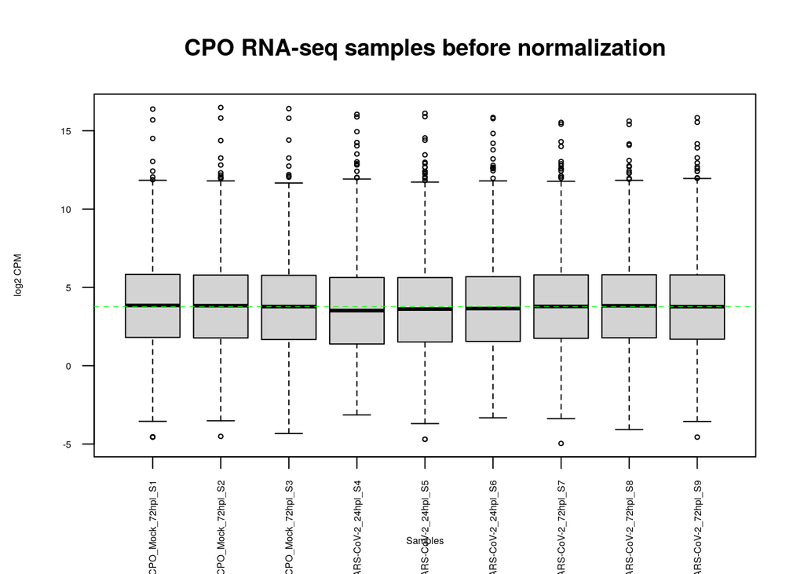

```r
# Transform counts per million to log2
boxData <- log2(edgeR::cpm(filteredCounts[, 2:10]))
boxplot(boxData, xlab = "Samples", ylab = "log2 CPM",
        las = 2, cex = 0.5, cex.lab = 0.5,
        cex.axis = 0.5, main = "CPO RNA-seq samples before normalization")

# Draw the median on each boxplot
abline(h = median(apply(boxData, 2, median)),
       col = "green", lwd = 0.6, lty = "dashed")
```

The boxplot shows similar distributions across all 9 samples, including the median, quantiles, and distribution of outliers.

### Density plot

Next, we will plot the density distribution of each sample as another way to assess the overall distribution of our dataset before normalization.

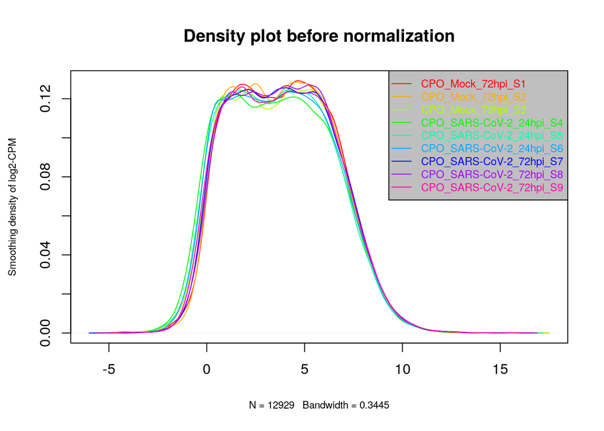

```r
countsDensity <- apply(log2(edgeR::cpm(filteredCounts[, 2:10])), 2, density)

# Calculate the axis limits across all 9 samples
xlim1 <- 0
ylim1 <- 0
for (i in 1:length(countsDensity)) {
  xlim1 <- range(c(xlim1, countsDensity[[i]]$x))
  ylim1 <- range(c(ylim1, countsDensity[[i]]$y))
}

cols1 <- rainbow(length(countsDensity))
ltys1 <- rep(1, length(countsDensity))

# Plot the first density plot
plot(countsDensity[[1]], xlim = xlim1, ylim = ylim1, type = "n",
     ylab = "Smoothing density of log2-CPM",
     main = "Density plot before normalization", cex.lab = 0.7)
# Plot each sample line
for (i in 1:length(countsDensity)) {
  lines(countsDensity[[i]], col = cols1[i], lty = ltys1[i])
}
legend("topright", colnames(boxData), col = cols1, lty = ltys1, cex = 0.75,
       border = "black", text.col = cols1, merge = TRUE, bg = "gray75")
```

The density plot seems to most closely follow both somewhat bimodal distribution. There is some variation between the samples, though the overall distributions are similar.

## Normalization by distribution

As recommended in lecture, Trimmed Mean of M-values (TMM) normalization is a specialized and commonly used method for RNA-seq data. TMM assumes that most genes are not differentially expressed, and that there are a similar number of up- and down- regulated genes in the data across samples.

```r
# Create DGEList object to be used by edgeR
filteredDataMatrix <- as.matrix(filteredCounts[, 2:10])
rownames(filteredDataMatrix) <-filteredCounts$gene_name
d = edgeR::DGEList(counts = filteredDataMatrix, group = samples$treatment_time)

# Calculate normalization factors
d = edgeR::calcNormFactors(d)
# Get normalized data in counts per million
normalizedCounts <- edgeR::cpm(d)
```

### Boxplot after normalization

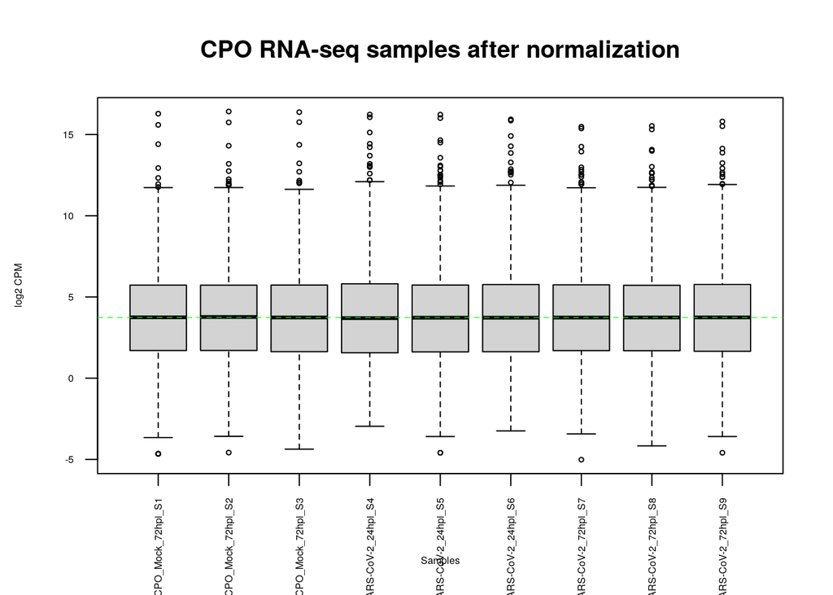

```r
# Transform normalized counts per million to log2
boxDataNorm <- log2(normalizedCounts)
boxplot(boxDataNorm, xlab = "Samples", ylab = "log2 CPM",
        las = 2, cex = 0.5, cex.lab = 0.5,
        cex.axis = 0.5, main = "CPO RNA-seq samples after normalization")

# Draw the median on each boxplot
abline(h = median(apply(boxDataNorm, 2, median)),
       col = "green", lwd = 0.6, lty = "dashed")
```

Comparing the boxplots before and after normalization, there are slight differences. Notably, the medians align visibly more closely after normalizing.

### Density plot after normalization

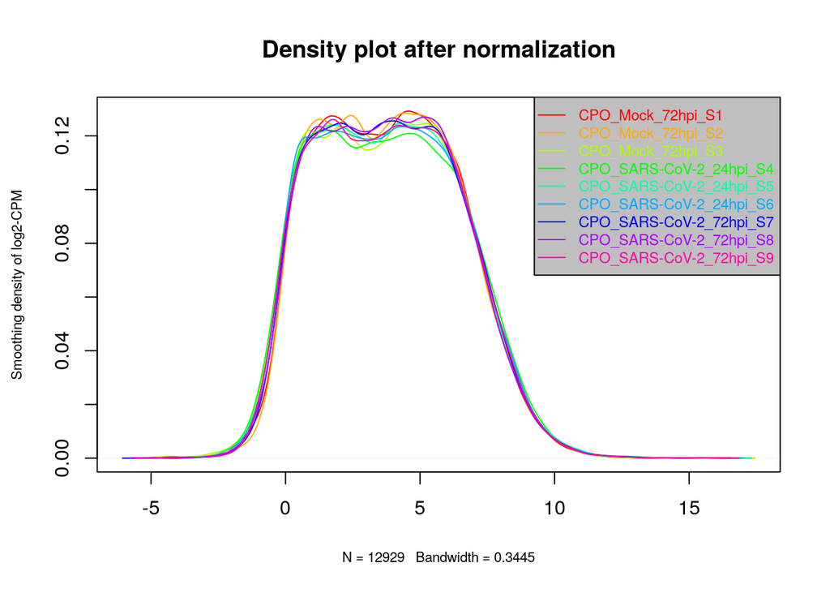

```r
countsDensityNorm <- apply(log2(normalizedCounts), 2, density)

# Calculate the axis limits across all 9 samples
xlim1 <- 0
ylim1 <- 0
for (i in 1:length(countsDensityNorm)) {
  xlim1 <- range(c(xlim1, countsDensityNorm[[i]]$x))
  ylim1 <- range(c(ylim1, countsDensityNorm[[i]]$y))
}

cols1 <- rainbow(length(countsDensityNorm))
ltys1 <- rep(1, length(countsDensityNorm))

# Plot the first density plot
plot(countsDensityNorm[[1]], xlim = xlim1, ylim = ylim1, type = "n",
     ylab = "Smoothing density of log2-CPM",
     main = "Density plot after normalization", cex.lab = 0.7)
# Plot each sample line
for (i in 1:length(countsDensityNorm)) {
  lines(countsDensityNorm[[i]], col = cols1[i], lty = ltys1[i])
}
legend("topright", colnames(boxDataNorm), col = cols1, lty = ltys1, cex = 0.75,
       border = "black", text.col = cols1, merge = TRUE, bg = "gray75")
```

Similar to the boxplots, there do not appear to be significant differences between the density distrubtions before and after normalization. However, the sample plots after normalization show slightly less variance in some regions.

### MDS plot after normalization

A multidimensional scaling (MDS) plot shows distances between samples.

Using the normalization factors, plot the samples on an MDS plot.

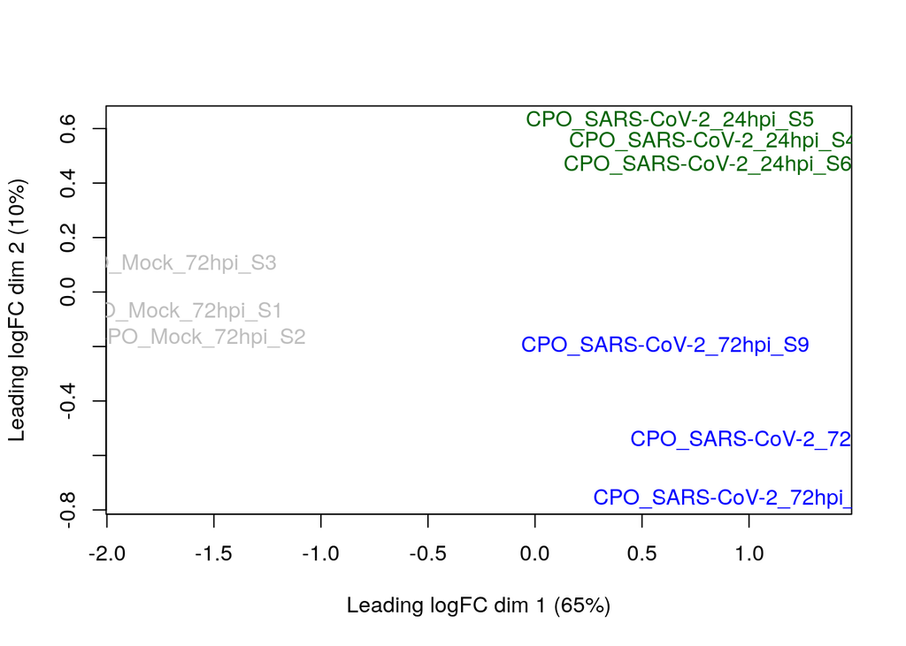

```r
limma::plotMDS(d, labels = rownames(samples),
        col = c("grey", "darkgreen", "blue") [factor(samples$treatment_time)])
```

After normalization, the three treatment_time groups each form a distinct cluster and are quite distant from each other. The SARS-CoV-2_24hpi group (green) is most closely clustered, followed by the Mock_72hpi group (grey), while SARS-CoV-2_72hpi (blue) samples are most distant from each other.

## Save the normalized dataset

Since the normalized dataset is in a DGEList, we can use edgeR to convert it to a matrix. Then, we can save the matrix as a csv file for ease of future analysis.

```r
normalizedDataMatrix <- edgeR::as.matrix.DGEList(d)
# Save to csv file in current directory with rownames as gene names
write.csv(normalizedDataMatrix, file = "normalized_gene_counts.csv", row.names = TRUE)
```

# Interpretation of normalized data

### What are the control and test conditions of the dataset?

The control conditions are the growth and infection protocols, which were identical apart from the experimental treatment (described below). The main test conditions are exposure to SARS-CoV-2 or the vehicle control treatment. For the virus-exposed brain organoids, there were also 2 timepoints of transcriptomic analysis: either 24 or 72 hours post-infection (hpi).

### Why is the dataset of interest to you?

Research on SARS-CoV-2 is constantly evolving, and the neurological effects of the virus are one of the areas that are not yet well understood, so I am particularly curious about it.

### Were there expression values that were not unique for specific genes? How did you handle these?

Based on the provided gene identifiers in the dataset, there were no duplicates.

### Were there expression values that could not be mapped to current HUGO symbols?

Yes, 1,584 expression values could not be mapped to current HUGO symbols. Given this relatively sizeable number (12% of genes after filtering out low counts), these unmapped genes are still kept in the dataset at this point.

### How many outliers were removed?

16,826 genes with low counts were removed from the dataset using edgeR.

### How did you handle replicates?

There are 3 replicates for each of the 3 treatment_time groups. In the normalization step, we took into account the 3 groups and used TMM, which is a sample-based method.

### What is the final coverage of your dataset?

The final coverage of my dataset is 12,929 genes and 9 samples.

# References

Chen, Yunshun, Aaron TL Lun, Davis J McCarthy, Matthew E Ritchie, Belinda Phipson, Yifang Hu, Xiaobei Zhou, Mark D Robinson, and Gordon K Smyth. 2022. *edgeR: Empirical Analysis of Digital Gene Expression Data in r*.

Davis, Sean. 2022. *GEOquery: Get Data from NCBI Gene Expression Omnibus (GEO)*.

Durinck, Steffen, and Wolfgang Huber. 2022. *biomaRt: Interface to BioMart Databases (i.e. Ensembl)*.

Isserlin, Ruth. 2023a. “BCB420. Lecture 4: Data Cleaning.”

———. 2023b. “BCB420. Lecture 4: Normalization.”

———. 2023c. “BCB420. Lecture 5: Data Exploration and Identifier Mapping.”

Jacob, Fadi, Sarshan R Pather, Wei-Kai Huang, Feng Zhang, Samuel Zheng Hao Wong, Haowen Zhou, Beatrice Cubitt, et al. 2020. “Human Pluripotent Stem Cell-Derived Neural Cells and Brain Organoids Reveal SARS-CoV-2 Neurotropism Predominates in Choroid Plexus Epithelium.” *Cell Stem Cell* 27 (6): 937–50.

Morgan, Martin. 2022. *BiocManager: Access the Bioconductor Project Package Repository*.

Smyth, Gordon, Yifang Hu, Matthew Ritchie, Jeremy Silver, James Wettenhall, Davis McCarthy, Di Wu, et al. 2022. *Limma: Linear Models for Microarray Data*. http://bioinf.wehi.edu.au/limma.

Xie, Yihui. 2022. *Knitr: A General-Purpose Package for Dynamic Report Generation in r*. https://yihui.org/knitr/.

Zhu, Jack, and Sean Davis. 2022. *GEOmetadb: A Compilation of Metadata from NCBI GEO*.